# 基金量化分析与预测报告书

量化金融系列

LiXin Wu

2019年6月02日

## 研究背景

```
 随着经济的发展和社会的进步,国民的个人财富也有了丰富的积累,这些财富急需进行有效的保值和增值服务.在此背景下,资产管理行业获得了前所未有的发展态势,迎来了**大资管时代**.在全球资产管理行业，以股票为代表的权益类资产是全球资管行业资产配置比重最大、最典型的一类资产,其次是基金.2017年由于新的**资管新规**要求未来理财产品必须完成净值化转型,理财产品的风险将逐步让渡给投资者,目前银行配置权益类资产的风险明显降低,配置意愿必然增长.
 权益类资产中股票和基金的投资具有很大的风险,作为个人投资者如何选择投资产品,实现财富有效的保值和增值呢？作为个人投资者我们比任何时候都迫切渴望提高自身产品选择能力,作者希望通过把国外金融公司先进的**量化金融技术**与**预测科学**,用通俗易懂的语言帮助投资者提高自身投资能力.
```

## 基金走势图

[figure not shown]

## 分析过去

分析过去帮助我们更好的了解这只基金,预测未来帮我们把握未来投资机会.

### 投资回报

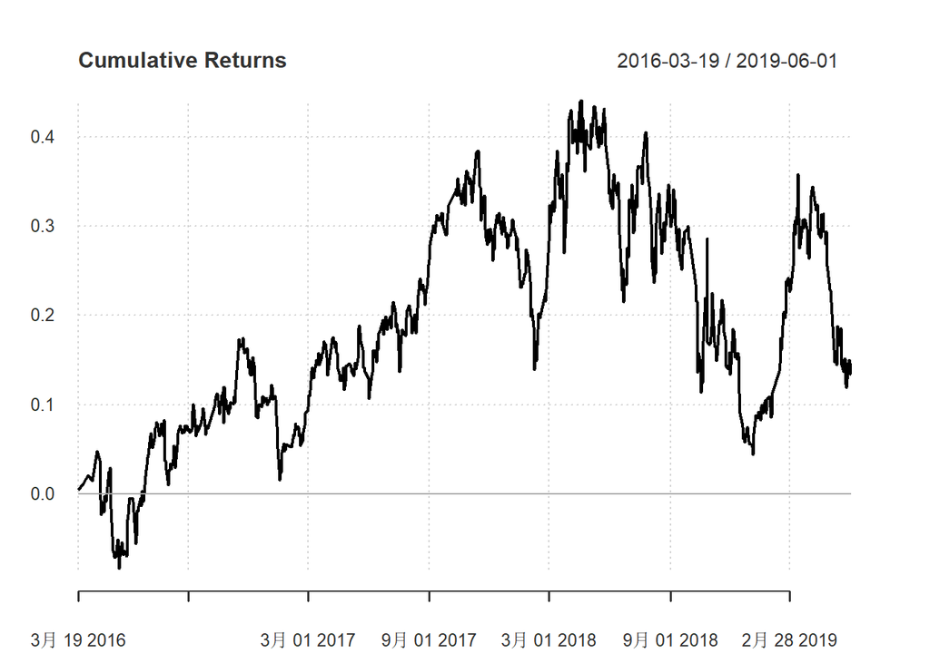

### 投资周期-季度VS月份

每一年不同季度,每个月的投资回报情况有助于我们了解投资周期和定投的周期.

[figure not shown]

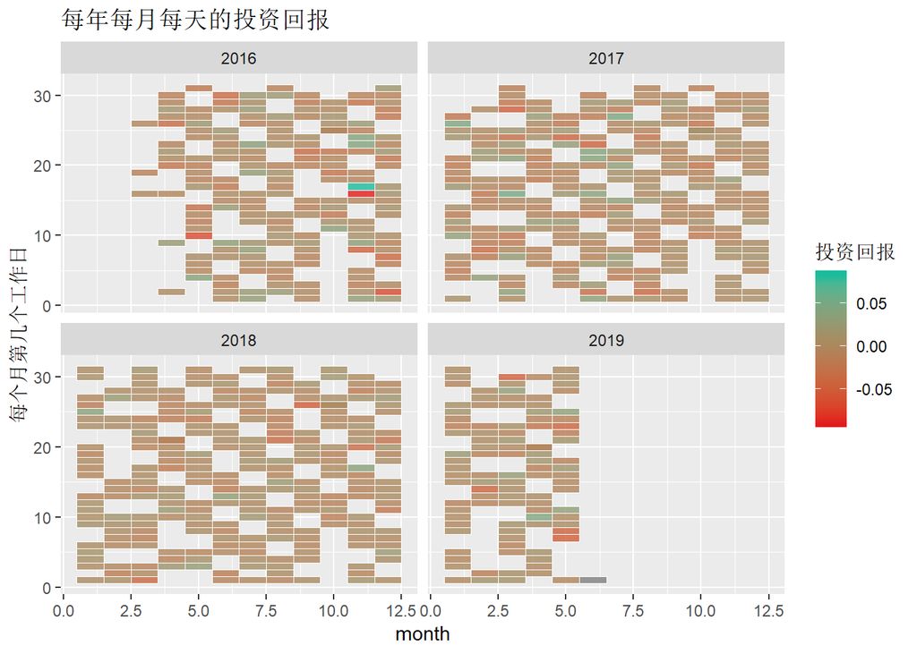

### 投资风险

一只赚钱的基金总是正的反弹比负的反弹多.正的波动产生的面积大于负的,根据面积图走势预测未来获利空间.

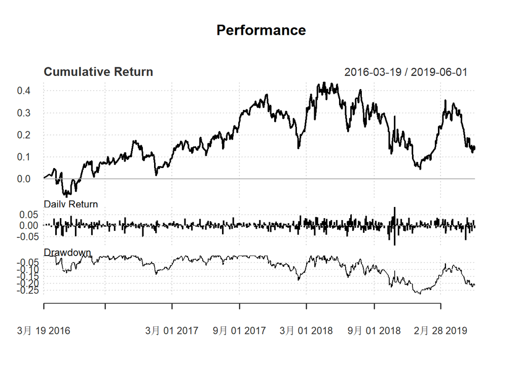

### 风险度量

风险度量,当一只基金突破边际风险线次数过多时,基本上很难赚钱.

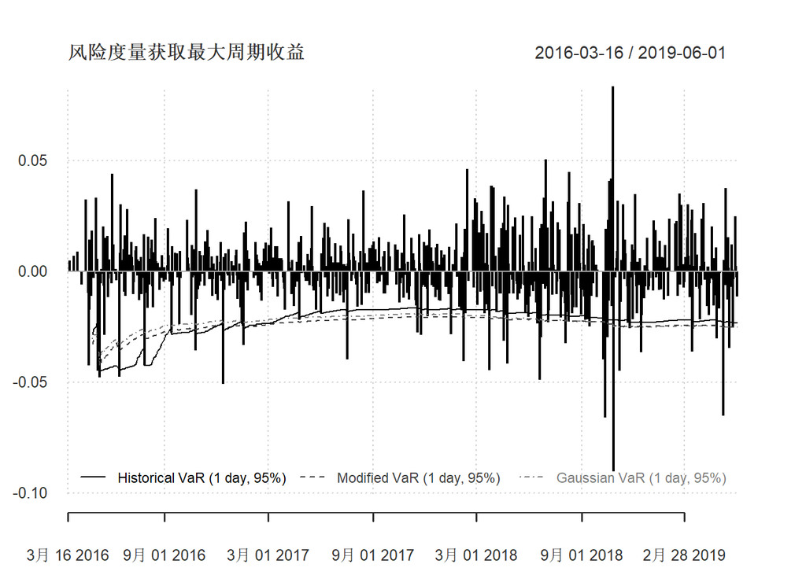

### 机会窗口

机会窗口期的次数衡量这只基金最佳买入时机上车的机会,一般如果一只基金大多数客户亏损,这只基金的买入机会是比较少的. through表示最佳买入时间点.

[output not shown]

## 预测未来

### 多元聚合预测(Multiple Aggregation Prediction)

```
## Running with 4 cores
```

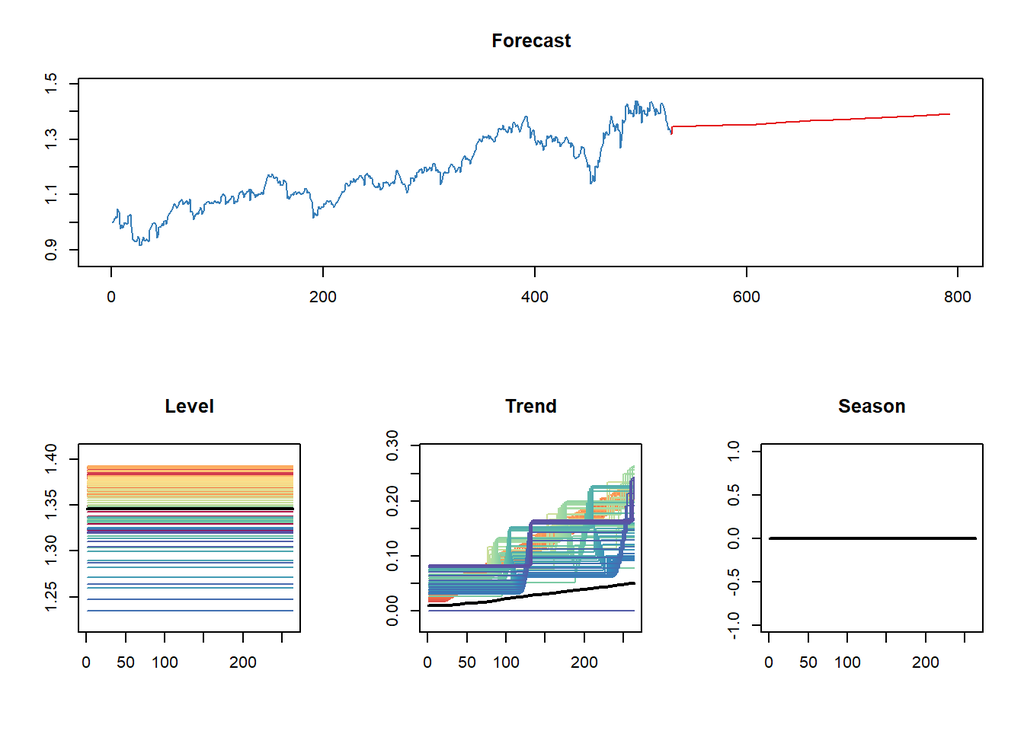

```
##      t+1      t+2      t+3      t+4      t+5      t+6      t+7      t+8
## 1.347481 1.347481 1.347481 1.347481 1.347481 1.347481 1.347481 1.347481
##      t+9     t+10     t+11     t+12     t+13     t+14     t+15     t+16
## 1.347481 1.347481 1.347481 1.347481 1.347481 1.347481 1.347481 1.347481
##     t+17     t+18     t+19     t+20     t+21     t+22     t+23     t+24
## 1.347481 1.347481 1.347481 1.347481 1.347481 1.347542 1.347607 1.347673
##     t+25     t+26     t+27     t+28     t+29     t+30     t+31     t+32
## 1.347743 1.347814 1.347890 1.347967 1.348048 1.348132 1.348220 1.348309
##     t+33     t+34     t+35     t+36     t+37     t+38     t+39     t+40
## 1.348400 1.348497 1.348597 1.348700 1.348800 1.348910 1.349019 1.349134
##     t+41     t+42     t+43     t+44     t+45     t+46     t+47     t+48
## 1.349251 1.349367 1.349547 1.349673 1.349867 1.349994 1.350194 1.350330
##     t+49     t+50     t+51     t+52     t+53     t+54     t+55     t+56
## 1.350538 1.350538 1.350609 1.350609 1.350684 1.350684 1.350762 1.350762
##     t+57     t+58     t+59     t+60     t+61     t+62     t+63     t+64
## 1.350843 1.350843 1.350927 1.350927 1.351015 1.351015 1.351103 1.351165
##     t+65     t+66     t+67     t+68     t+69     t+70     t+71     t+72
## 1.351257 1.351257 1.351417 1.351417 1.351518 1.351584 1.351687 1.351687
##     t+73     t+74     t+75     t+76     t+77     t+78     t+79     t+80
## 1.351857 1.351857 1.351967 1.352038 1.352369 1.352579 1.352965 1.353160
##     t+81     t+82     t+83     t+84     t+85     t+86     t+87     t+88
## 1.353420 1.353679 1.354014 1.354250 1.354746 1.354988 1.355361 1.355695
##     t+89     t+90     t+91     t+92     t+93     t+94     t+95     t+96
## 1.356141 1.356339 1.356749 1.356938 1.357309 1.357548 1.357782 1.357904
##     t+97     t+98     t+99    t+100    t+101    t+102    t+103    t+104
## 1.358355 1.358523 1.358707 1.359002 1.359296 1.359545 1.359921 1.360202
##    t+105    t+106    t+107    t+108    t+109    t+110    t+111    t+112
## 1.360565 1.361015 1.361217 1.361405 1.361761 1.361933 1.362160 1.362421
##    t+113    t+114    t+115    t+116    t+117    t+118    t+119    t+120
## 1.362642 1.362769 1.362999 1.363184 1.363387 1.363618 1.363734 1.363853
##    t+121    t+122    t+123    t+124    t+125    t+126    t+127    t+128
## 1.364253 1.364384 1.364532 1.364811 1.365084 1.365368 1.365790 1.366059
##    t+129    t+130    t+131    t+132    t+133    t+134    t+135    t+136
## 1.366151 1.366576 1.366956 1.367264 1.367867 1.367867 1.367867 1.368072
##    t+137    t+138    t+139    t+140    t+141    t+142    t+143    t+144
## 1.368172 1.368172 1.368372 1.368372 1.368556 1.368691 1.368691 1.368691
##    t+145    t+146    t+147    t+148    t+149    t+150    t+151    t+152
## 1.369000 1.369084 1.369084 1.369145 1.369255 1.369255 1.369415 1.369415
##    t+153    t+154    t+155    t+156    t+157    t+158    t+159    t+160
## 1.369745 1.369745 1.370020 1.370108 1.370494 1.370494 1.370689 1.370689
```

[output cut: 11 more lines]

```
## 1.378335 1.378335 1.378584 1.378668 1.379044 1.379159 1.379440 1.379507
##    t+209    t+210    t+211    t+212    t+213    t+214    t+215    t+216
## 1.379870 1.379870 1.380527 1.380527 1.380729 1.380729 1.380917 1.381043
##    t+217    t+218    t+219    t+220    t+221    t+222    t+223    t+224
## 1.381469 1.381558 1.381730 1.381730 1.382085 1.382085 1.382347 1.382347
##    t+225    t+226    t+227    t+228    t+229    t+230    t+231    t+232
## 1.382660 1.382859 1.382985 1.382985 1.383437 1.383437 1.383755 1.384123
##    t+233    t+234    t+235    t+236    t+237    t+238    t+239    t+240
## 1.384326 1.384326 1.384828 1.384963 1.385080 1.385275 1.385494 1.385494
##    t+241    t+242    t+243    t+244    t+245    t+246    t+247    t+248
## 1.386176 1.386176 1.386371 1.386629 1.386777 1.386880 1.387379 1.387379
##    t+249    t+250    t+251    t+252    t+253    t+254    t+255    t+256
## 1.387652 1.387888 1.388171 1.388171 1.389010 1.389076 1.389346 1.389588
##    t+257    t+258    t+259    t+260    t+261    t+262    t+263
## 1.389680 1.389680 1.390351 1.390462 1.390842 1.391176 1.391484
```

## 关于作者(About me)

LiXin Wu,a young data scientist,be good at target marketing,quantitative analysis,customer management,natural language analyst,and spatial data analyst. 欢迎交流邮箱wlx521@outlook.com 个人网页https://wulixin.github.io//QuandlFinance//home.html